# (PDF) Contingent claims approach to measuring and managing sovereign credit risk

ArticlePDF Available

# Contingent claims approach to measuring and managing sovereign credit risk

- January 2008
- [Journal of Investment and Management](https://www.researchgate.net/journal/Journal-of-Investment-and-Management-2328-7713) 5(4)

Authors:

[Dale F. Gray](https://www.researchgate.net/profile/Dale-Gray-2)

- [International Monetary Fund](https://www.researchgate.net/institution/International_Monetary_Fund)

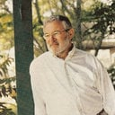

[Zvi Bodie](https://www.researchgate.net/profile/Zvi-Bodie)

- [Boston University](https://www.researchgate.net/institution/Boston-University)

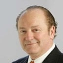

[Robert C. Merton](https://www.researchgate.net/profile/Robert-Merton-2)

- [Massachusetts Institute of Technology](https://www.researchgate.net/institution/Massachusetts-Institute-of-Technology)

## Abstract

This paper proposes a new approach to measure, analyze, and manage sovereign risk based on the theory and practice of modern contingent claims analysis (CCA). The paper provides a new framework for adapting the CCA model to the sovereign balance sheet in a way that can help forecast credit spreads and evaluate the impact of market risks and risks transferred rom other sectors. This new framework is useful for assessing vulnerability, policy analysis, sovereign credit risk analysis, and design of sovereign risk mitigation and control strategies. Applications for investors in three areas are discussed. First, CCA provides a new framework for valuing, investing, and trading sovereign securities, including sovereign capital structure arbitrage. Second, it provides a new framework for analysis and management of sovereign wealth funds being created by many emerging market and resource rich countries. Third, the framework provides quantitative measures of sovereign risk exposures which facilitates the design of new instruments and contracts to control or transfer sovereign risk.

**Discover the world's research**

Content uploaded by [Robert C. Merton](https://www.researchgate.net/profile/Robert-Merton-2)

Author content

All content in this area was uploaded by Robert C. Merton on May 19, 2016

Content may be subject to copyright.

JOIM

www.joim.com

JOURNAL OFINVESTMENT MANAGEMENT, Vol. 5, No. 4, (2007), pp. 5–28

© JOIM 2007

CONTINGENT CLAIMS APPROACH TO MEASURING

AND MANAGING SOVEREIGN CREDIT RISK

Dale F. Graya, Robert C. Mertonband Zvi Bodiec

This paper proposes a new approach to measure, analyze, and manage sovereign risk based

on the theory and practice of modern contingent claims analysis (CCA). The paper provides

a new framework for adapting the CCA model to the sovereign balance sheet in a way that

can help forecast credit spreads and evaluate the impact of market risks and risks transferred

from other sectors. This new framework is useful for assessing vulnerability, policy analysis,

sovereign credit risk analysis, and design of sovereign risk mitigation and control strategies.

Applications for investors in three areas are discussed. First, CCA provides a new framework

for valuing, investing, and trading sovereign securities, including sovereign capital structure

arbitrage. Second, it provides a new framework for analysis and management of sovereign

wealth funds being created by many emerging market and resource rich countries. Third,

the framework provides quantitative measures of sovereign risk exposures which facilitates

the design of new instruments and contracts to control or transfer sovereign risk.

0 Introduction

Vulnerability of a national economy to volatility in

the global markets for credit, currencies, commodi-

ties, and other assets has become a central concern

national Monetary Fund, and President of MF Risk, Inc.

E-mail: dgray@imf.org and dgray@mfrisk.com.

bJohn and Natty McArthur University Professor, Harvard

Business School, E-mail: rmerton@hbs.edu.

cNorman and Adele Barron Professor of Management, Boston

University School of Management, E-mail: zbodie@bu.edu.

of policymakers, credit analysts, and investors

everywhere. This paper proposes a new compre-

hensive approach to measure, analyze, and manage

sovereign risk based on the theory and practice of

modern contingent claims analysis (CCA). In this

approach, the sectors of a national economy are

viewed as interconnected portfolios of assets, liabil-

ities, and guarantees. We measure the sensitivities

of the market values of these portfolios to “shocks”

in underlying market risk factors, and we illustrate

how to use contingent claims analysis to quantify

[Predicting Credit Default Risk Crisis of Government Implicit Debt: An Interpretable Machine Learning Approach](https://www.researchgate.net/publication/392529131_Predicting_Credit_Default_Risk_Crisis_of_Government_Implicit_Debt_An_Interpretable_Machine_Learning_Approach)

Article

Full-text available

- Jun 2025
- Comput Econ
- [Pan Tang](https://www.researchgate.net/scientific-contributions/Pan-Tang-2235850810)
- [Xiantao Wang](https://www.researchgate.net/scientific-contributions/Xiantao-Wang-2270272552)
- [Qingying Han](https://www.researchgate.net/scientific-contributions/Qingying-Han-2235848638)
- [Rui Dong](https://www.researchgate.net/scientific-contributions/Rui-Dong-2315711972)

Local government implicit debt is a key financing tool for local infrastructure, supporting regional investment through various financing platforms. However, the low short-term default risk and high credit ratings of government implicit debt limit effective credit risk identification, distorting risk pricing. This study employs interpretable machine learning models and post-hoc explainability methods to analyze urban investment bonds (UIBs) credit risk in China from 2015 to 2023. Findings reveal that basic bond characteristics (amount, bond rating) and macroeconomic indicators (monetary policy, market sentiment) are the most influential factors, with regional economic conditions and issuer financial status also playing significant roles. To enhance risk assessment, this study combines the best-performing interpretable EBM model, with the most effective traditional Random Forest model, for a comprehensive predictive analysis. This approach improves both interpretability and accuracy, offering policymakers, investors, and regulators a robust data-driven risk management tool.

[View](https://www.researchgate.net/publication/392529131_Predicting_Credit_Default_Risk_Crisis_of_Government_Implicit_Debt_An_Interpretable_Machine_Learning_Approach)

... En utilisant les cotations du marché des taux sans risque et primes de risque pays, ils calibrent un modèle de type Merton grâce à la formule de Black et Scholes pour une option de vente. Par contre, Gray et al. (2007) proposent une autre approche pour mesurer, analyser et gérer le risque souverain, basée sur la théorie et la pratique de l'analyse moderne des créances contingentes (CCA). De même, Lai (2016) évalue le risque de crédit des ménages et du gouvernement à Singapour en utilisant l'approche des CCA, dans le but d'estimer leur probabilité de défaut sur la base de la valeur de marché de leurs actifs et de leurs passifs. ...

[Le modèle hybride de la structure par terme des primes souveraines de crédit et de liquidité dans la zone UEMOA](https://www.researchgate.net/publication/372502770_Le_modele_hybride_de_la_structure_par_terme_des_primes_souveraines_de_credit_et_de_liquidite_dans_la_zone_UEMOA)

Article

Full-text available

- Jul 2023
- [Lambert N'galadjo Bamba](https://www.researchgate.net/profile/Lambert-Bamba)
- [Florent Gbongue](https://www.researchgate.net/profile/Florent-Gbongue)

Résumé – Dans le contexte actuel, la soutenabilité de la dette publique est devenue une problématique cruciale pour la plupart des pays africains. Pour les pays de la zone UEMOA, cette soutenabilité est affectée par des primes souveraines implicites (PSI) sur le marché financier régional (MFR), qui constituent une mesure essentielle de la perception du risque des émetteurs souverains. Cet article apporte des innovations méthodologiques aux travaux de Merrick (2001) et Gbongué et Bamba (2022) en proposant des modèles hybrides de détermination des PSI indirectes et particulièrement une solution au calibrage de la forme fonctionnelle du risque de liquidité, ce qui permet d’améliorer sensiblement l’estimation du coefficient de variation, ainsi que le taux de recouvrement implicite en cas de défaut de l’émetteur souverain. L’application sur la période 2015-2022 révèle que les structures par terme des primes souveraines de crédit et liquidité des pays de l’UEMOA sont stables lorsqu’elles sont estimées par des modèles hybrides, composés des modèles de Gumbel à l’interpolation et Log-Normale à l’extrapolation, ce qui améliore la visibilité du MFR à moyen et long terme. Ces PSI sont sensibles aux décisions de politique monétaire et aux paramètres de la courbe des taux sans risque, dont le calibrage mérite une attention particulière. Aussi, l’étude recommande-t-elle la poursuite de l’objectif de stabilité des prix par les autorités monétaires, ainsi qu’une meilleure coordination entre les politiques monétaire et budgétaire, comme garant de la stabilité de la courbe des taux de marché et, partant, d’une gestion efficiente des finances publiques dans l’Union.

[View](https://www.researchgate.net/publication/372502770_Le_modele_hybride_de_la_structure_par_terme_des_primes_souveraines_de_credit_et_de_liquidite_dans_la_zone_UEMOA)

[Région et Développement Le modèle hybride de la structure par terme des primes souveraines de crédit et de liquidité dans la zone UEMOA](https://www.researchgate.net/publication/372502029_Region_et_Developpement_Le_modele_hybride_de_la_structure_par_terme_des_primes_souveraines_de_credit_et_de_liquidite_dans_la_zone_UEMOA)

Article

- Jun 2023
- [Florent Kanga](https://www.researchgate.net/scientific-contributions/Florent-Kanga-2256639521)
- [Lambert N'galadjo Bamba](https://www.researchgate.net/scientific-contributions/Lambert-Ngaladjo-Bamba-2256552299)

In the current context, public debt sustainability has become a crucial issue for most African countries. In WAEMU countries, this sustainability is affected by implicit sovereign premiums (ISP) on the regional financial market (RFM), which are an essential measure of the perception of implicit risk of sovereign issuers. This paper brings methodological innovations to the work of Merrick (2001) and Gbongué and Bamba (2022), by proposing hybrid models for the determination of indirect ISPs and, in particular, a solution to the calibration of the liquidity risk functional, considerably improving the estimation of the coefficient of variation, as well as the implied recovery rate in case of sovereign default. With data covering the period 2015-2022, the empirical application reveals that the term structures of the sovereign credit and liquidity premia of WAEMU countries are stable when estimated by hybrid models, composed of Gumbel interpolation and Log-Normal extrapolation models, which improves the visibility of the mediumand long-term RFM. These ISPs are sensitive to monetary policy decisions and riskfree yield curve parameters, the calibration of which deserves particular attention. The study therefore recommends that the monetary authorities should pursue the objective of price stability and that there should be better coordination between monetary and fiscal policies to ensure the stability of the market yield curve and hence the efficient management of public finances in the Union.

[View](https://www.researchgate.net/publication/372502029_Region_et_Developpement_Le_modele_hybride_de_la_structure_par_terme_des_primes_souveraines_de_credit_et_de_liquidite_dans_la_zone_UEMOA)

[Robert C. Merton (1944–)](https://www.researchgate.net/publication/393583345_Robert_C_Merton_1944-)

Chapter

- Jul 2025
- [Zvi Bodie](https://www.researchgate.net/profile/Zvi-Bodie)
- [Andrew W. Lo](https://www.researchgate.net/scientific-contributions/Andrew-W-Lo-2246736386)

Robert C. Merton is the School of Management Distinguished Professor of Finance at Massachusetts Institute of Technology (MIT), and the John and Natty McArthur University Professor Emeritus at Harvard University. Merton received the Nobel Memorial Prize in Economic Sciences in 1997 for a new method to determine the value of derivatives. After receiving a PhD in economics from MIT in 1970, Merton joined the MIT Sloan School finance faculty until 1988, at which time he was J.C. Penney Professor of Management. Merton’s research focuses on finance theory, including life-cycle and retirement finance, optimal portfolio selection, capital asset pricing, pricing of derivative securities, credit risk, loan guarantees, financial innovation, the dynamics of institutional change, and improving the methods of measuring and managing macro-financial systemic risk. He received a BS in engineering mathematics from Columbia University, an MS in applied mathematics from the California Institute of Technology and a PhD in economics from MIT.

[View](https://www.researchgate.net/publication/393583345_Robert_C_Merton_1944-)

[Public debt bubble and deflation: evidence from the Big Government impact in China](https://www.researchgate.net/publication/391976308_Public_debt_bubble_and_deflation_evidence_from_the_Big_Government_impact_in_China)

Article

- May 2025
- J POST KEYNESIAN EC
- [Xinda Li](https://www.researchgate.net/profile/Xinda-Li-7)
- [Xuefeng Shao](https://www.researchgate.net/scientific-contributions/Xuefeng-Shao-2278336061)
- [Hualu Shao](https://www.researchgate.net/profile/Hualu-Shao)

This study extends Minsky’s framework by theorizing on how interventions designed to contain instability may inadvertently seed future fragility. We show that financial instability theory applies to public debt financing, which can trigger downward financial instability, leading to severe depressions, and upward financial instability, leading to severe inflation. The primary mechanism underlying this inherent fragility lies in the interplay in the economic growth model reliant on government investment, asset price fluctuations, and the liquidity amplification. We found some evidence in China supportive of this, where it serves as the best example of financial instability being “inherent,” in line with Minsky’s hypothesis. We explain why increased attention is needed to the endogenous instability of domestic government debt.

[View](https://www.researchgate.net/publication/391976308_Public_debt_bubble_and_deflation_evidence_from_the_Big_Government_impact_in_China)

[Spatial correlation of local government implicit debt tail risks in China and its spillover effects on the banking system](https://www.researchgate.net/publication/384273464_Spatial_correlation_of_local_government_implicit_debt_tail_risks_in_China_and_its_spillover_effects_on_the_banking_system)

Article

- Sep 2024
- Int Rev Financ Anal
- [Bohui Wen](https://www.researchgate.net/scientific-contributions/Bohui-Wen-2163616177)
- [Jiaxiang Xu](https://www.researchgate.net/scientific-contributions/Jiaxiang-Xu-2293248632)
- [Li Zhang](https://www.researchgate.net/scientific-contributions/Li-Zhang-2293250068)
- [Zhongyi Zhang](https://www.researchgate.net/scientific-contributions/Zhongyi-Zhang-2293255047)

[View](https://www.researchgate.net/publication/384273464_Spatial_correlation_of_local_government_implicit_debt_tail_risks_in_China_and_its_spillover_effects_on_the_banking_system)

[Public Debt Bubble and Deflation: Evidence on the Relationship Between Chinese Government Debt and the Financial System](https://www.researchgate.net/publication/380745999_Public_Debt_Bubble_and_Deflation_Evidence_on_the_Relationship_Between_Chinese_Government_Debt_and_the_Financial_System)

Article

- Jan 2024
- [xinda li](https://www.researchgate.net/scientific-contributions/xinda-li-2314273842)
- [Xuefeng Shao](https://www.researchgate.net/scientific-contributions/Xuefeng-Shao-2278336061)
- [Hualu Shao](https://www.researchgate.net/profile/Hualu-Shao)

[View](https://www.researchgate.net/publication/380745999_Public_Debt_Bubble_and_Deflation_Evidence_on_the_Relationship_Between_Chinese_Government_Debt_and_the_Financial_System)

[Contingent claim analysis and Minsky’s financial instability hypothesis](https://www.researchgate.net/publication/379865319_Contingent_claim_analysis_and_Minsky's_financial_instability_hypothesis)

Article

- Apr 2024
- [George Dotsis](https://www.researchgate.net/profile/George-Dotsis-2)
- [Konstantinos Loizos](https://www.researchgate.net/profile/Konstantinos-Loizos)

[View](https://www.researchgate.net/publication/379865319_Contingent_claim_analysis_and_Minsky's_financial_instability_hypothesis)

[Indispensable Source of Risk Contagion With Big Data Analysis From a More Comprehensive View on Shadow Banking](https://www.researchgate.net/publication/378785947_Indispensable_Source_of_Risk_Contagion_With_Big_Data_Analysis_From_a_More_Comprehensive_View_on_Shadow_Banking)

Article

Full-text available

- Mar 2024
- [J GLOB INF MANAG](https://www.researchgate.net/journal/Journal-of-Global-Information-Management-1533-7995)
- [Peijin Li](https://www.researchgate.net/scientific-contributions/Peijin-Li-2269506967)
- [Xiutong Yi](https://www.researchgate.net/scientific-contributions/Xiutong-Yi-2275692766)
- [Chonghui Zhang](https://www.researchgate.net/scientific-contributions/Chonghui-Zhang-2269470109)
- [Tomas Balezentis](https://www.researchgate.net/profile/Tomas-Balezentis)

Although shadow banking widely exists in the financial systems of various countries, their definitions vary significantly due to specific economic and financial characteristics. This paper classifies Chinese shadow banking into six categories: securities, trust, private lending, banking, fund, and insurance. The AR-GARCH-DCC model is used to measure systemic risk spillover through from an industrial and institutional perspective. The network topology index is employed to analyze risk contagion and further explore influencing factors. Firstly, based on the results of the AR-GARCH-DCC, the estimated dynamic volatility (σ) indicates that shadow banking risk spillover is time-varying, especially in trust and securities. Second, according to the static risk spillover analysis, various institutions play different roles and can transform between risk spillovers and overflowers. Thirdly, eigenvector centrality, leverage, assets, CPI, and macroeconomic prosperity significantly impact shadow banking systemic risk spillover.

[View](https://www.researchgate.net/publication/378785947_Indispensable_Source_of_Risk_Contagion_With_Big_Data_Analysis_From_a_More_Comprehensive_View_on_Shadow_Banking)

[A Rank Estimator Approach to Modeling Default Frequencies](https://www.researchgate.net/publication/375501026_A_Rank_Estimator_Approach_to_Modeling_Default_Frequencies)

Article

- Jan 2023
- [Antti Harju](https://www.researchgate.net/scientific-contributions/Antti-Harju-2248056099)

[View](https://www.researchgate.net/publication/375501026_A_Rank_Estimator_Approach_to_Modeling_Default_Frequencies)

## Recommended publications

Discover more about: [Credit Risk](https://www.researchgate.net/topic/Credit-Risk)

Article

### [A New Framework for Analyzing and Managing Macrofinancial Risks of an Economy](https://www.researchgate.net/publication/5187488_A_New_Framework_for_Analyzing_and_Managing_Macrofinancial_Risks_of_an_Economy)

November 2006 · SSRN Electronic Journal

- [Dale F. Gray](https://www.researchgate.net/profile/Dale-Gray-2)
- [Robert C. Merton](https://www.researchgate.net/profile/Robert-Merton-2)
- [Zvi Bodie](https://www.researchgate.net/profile/Zvi-Bodie)

The high cost of international economic and financial crises highlights the need for a comprehensive framework to assess the robustness of national economic and financial systems. This paper proposes a new comprehensive approach to measure, analyze, and manage macroeconomic risk based on the theory and practice of modern contingent claims analysis (CCA). We illustrate how to use the CCA approach ... [Show full abstract] to model and measure sectoral and national risk exposures, and analyze policies to offset their potentially harmful effects. This new framework provides economic balance sheets for inter-linked sectors and a risk accounting framework for an economy. CCA provides a natural framework for analysis of mismatches between an entity's assets and liabilities, such as currency and maturity mismatches on balance sheets. Policies or actions that reduce these mismatches will help reduce risk and vulnerability. It also provides a new framework for sovereign capital structure analysis. It is useful for assessing vulnerability, policy analysis, risk management, investment analysis, and design of risk control strategies. Both public and private sector participants can benefit from pursuing ways to facilitate more efficient macro risk accounting, improve price and volatility discovery, and expand international risk intermediation activities.

[Read more](https://www.researchgate.net/publication/5187488_A_New_Framework_for_Analyzing_and_Managing_Macrofinancial_Risks_of_an_Economy)

Article

Full-text available

### [Contingent claims approach to measuring and managing sovereign credit risk](https://www.researchgate.net/publication/228680898_Contingent_claims_approach_to_measuring_and_managing_sovereign_credit_risk)

August 2007

- [Dale F. Gray](https://www.researchgate.net/profile/Dale-Gray-2)
- [Robert C. Merton](https://www.researchgate.net/profile/Robert-Merton-2)
- [Zvi Bodie](https://www.researchgate.net/profile/Zvi-Bodie)
- [...]
- [Adele Barron Professor](https://www.researchgate.net/scientific-contributions/Adele-Barron-Professor-81687467)

[View full-text](https://www.researchgate.net/publication/228680898_Contingent_claims_approach_to_measuring_and_managing_sovereign_credit_risk)

Article

Full-text available

### [New Framework for Measuring and Managing Financial Risk and Financial Stability](https://www.researchgate.net/publication/5188555_New_Framework_for_Measuring_and_Managing_Financial_Risk_and_Financial_Stability)

December 2007

- [Dale F. Gray](https://www.researchgate.net/profile/Dale-Gray-2)
- [Robert C. Merton](https://www.researchgate.net/profile/Robert-Merton-2)
- [Zvi Bodie](https://www.researchgate.net/profile/Zvi-Bodie)

This paper proposes a new approach to improve the way central banks can analyze and manage the financial risks of a national economy. It is based on the modern theory and practice of contingent claims analysis (CCA), which is successfully used today at the level of individual banks by managers, investors, and regulators. The basic analytical tool is the risk-adjusted balance sheet, which shows ... [Show full abstract] the sensitivity of the enterprise's assets and liabilities to external "shocks." At the national level, the sectors of an economy are viewed as interconnected portfolios of assets, liabilities, and guarantees -- some explicit and others implicit. Traditional approaches have difficulty analyzing how risks can accumulate gradually and then suddenly erupt in a full-blown crisis. The CCA approach is well-suited to capturing such "non-linearities" and to quantifying the effects of asset-liability mismatches within and across institutions. Risk-adjusted CCA balance sheets facilitate simulations and stress testing to evaluate the potential impact of policies to manage systemic risk.

[View full-text](https://www.researchgate.net/publication/5188555_New_Framework_for_Measuring_and_Managing_Financial_Risk_and_Financial_Stability)

Article

Full-text available

### [A New Framework for Measuring and Managing Macrofinancial Risk and Financial Stability](https://www.researchgate.net/publication/43106070_A_New_Framework_for_Measuring_and_Managing_Macrofinancial_Risk_and_Financial_Stability)

January 2007

- [Dale F. Gray](https://www.researchgate.net/profile/Dale-Gray-2)
- [Robert C. Merton](https://www.researchgate.net/profile/Robert-Merton-2)
- [Zvi Bodie](https://www.researchgate.net/profile/Zvi-Bodie)

[View full-text](https://www.researchgate.net/publication/43106070_A_New_Framework_for_Measuring_and_Managing_Macrofinancial_Risk_and_Financial_Stability)

Chapter

Full-text available

### [Contingent Claims Approach to Measuring and Managing Sovereign Credit Risk](https://www.researchgate.net/publication/332006412_Contingent_Claims_Approach_to_Measuring_and_Managing_Sovereign_Credit_Risk)

March 2019

- [Dale F. Gray](https://www.researchgate.net/profile/Dale-Gray-2)
- [Robert C. Merton](https://www.researchgate.net/profile/Robert-Merton-2)
- [Zvi Bodie](https://www.researchgate.net/profile/Zvi-Bodie)

[View full-text](https://www.researchgate.net/publication/332006412_Contingent_Claims_Approach_to_Measuring_and_Managing_Sovereign_Credit_Risk)

Last Updated: 06 Aug 2025

Interested in research on Credit Risk?

or

[Discover by subject area](https://www.researchgate.net/topics)